# ELECTRIC HOUSEHOLD POWER CONSUMPTION

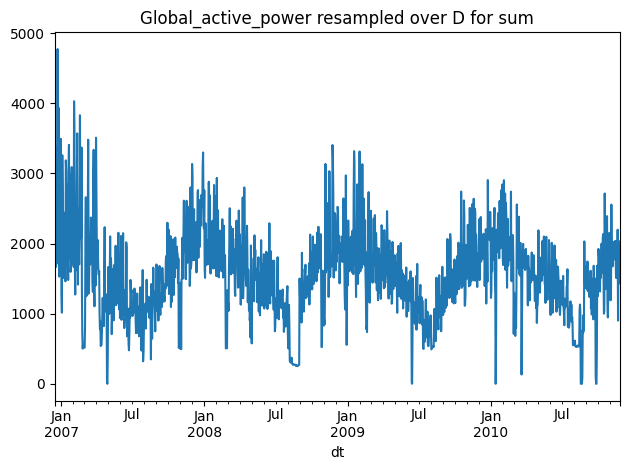

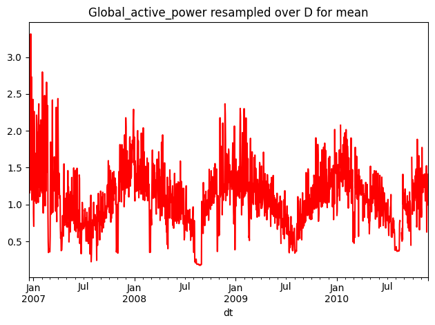

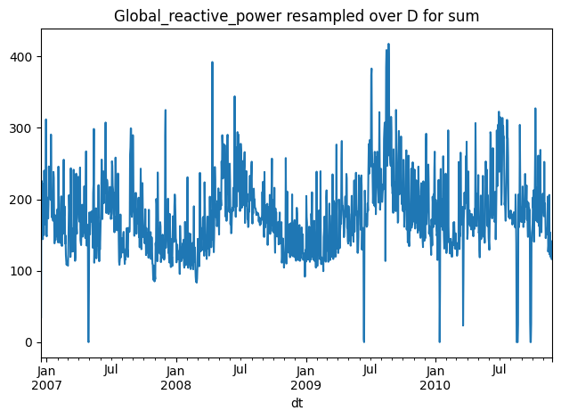

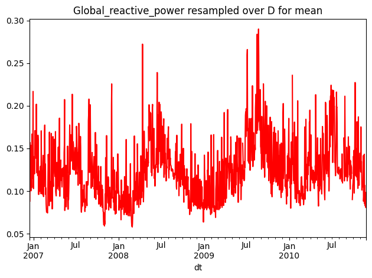

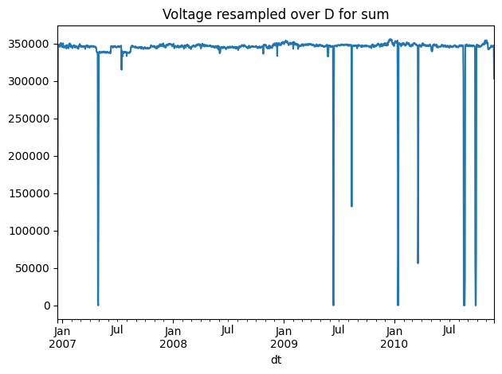

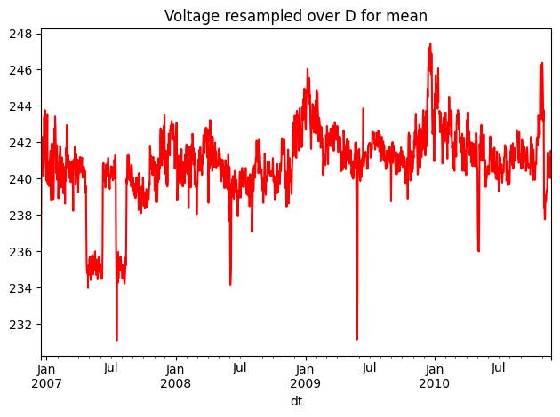

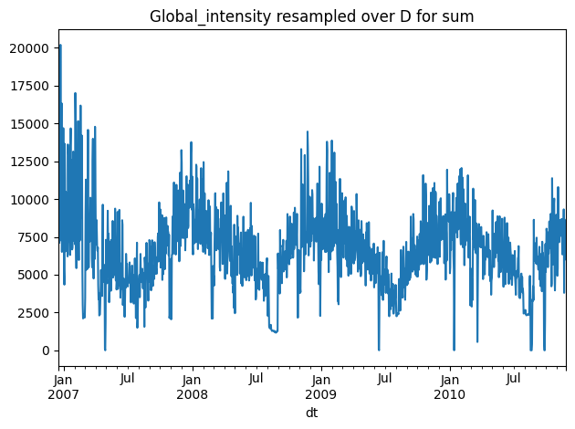

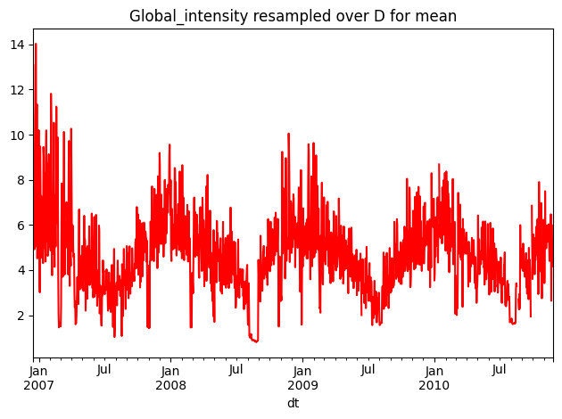

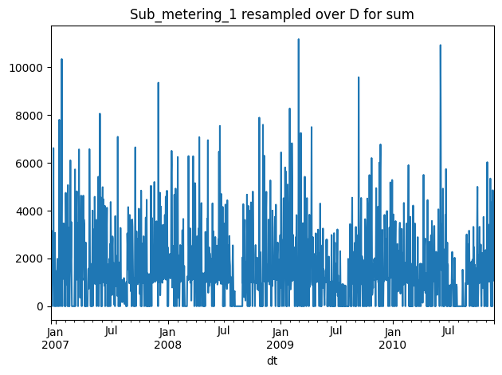

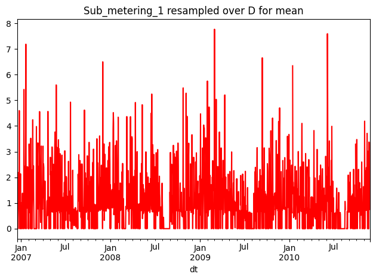

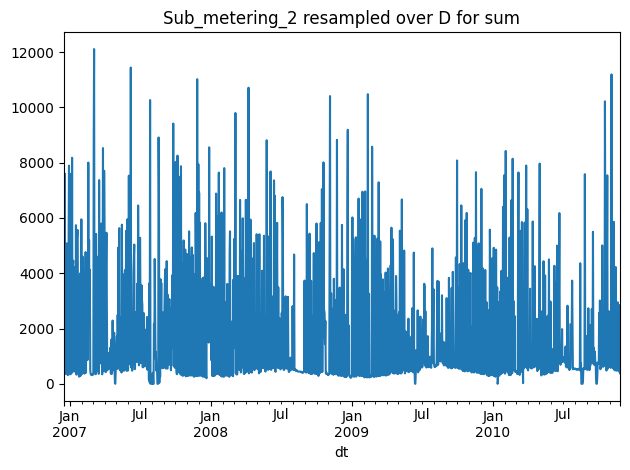

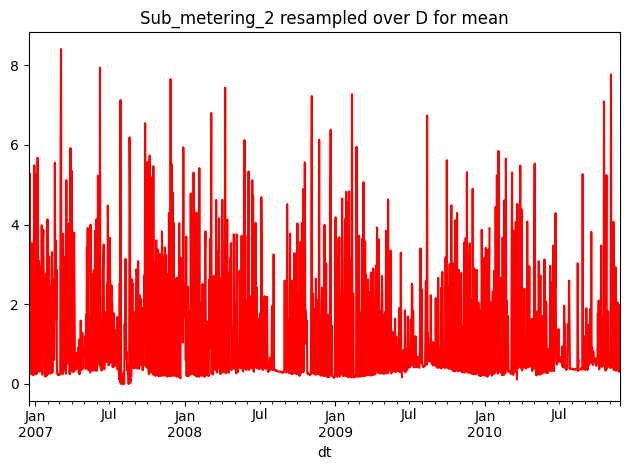

[2 more figures not shown]

```python
for col in data.columns:
    trend_plot(col, 'D')
```

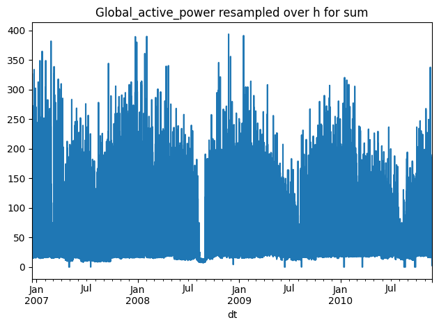

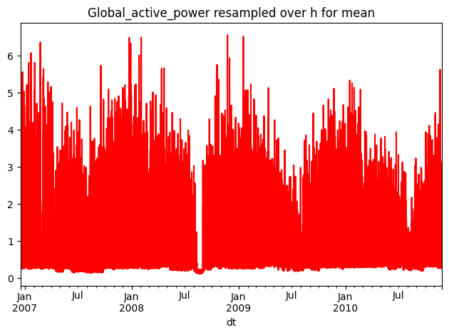

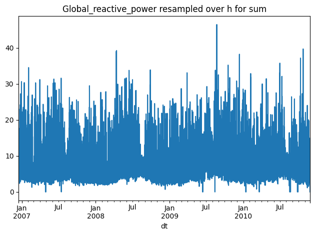

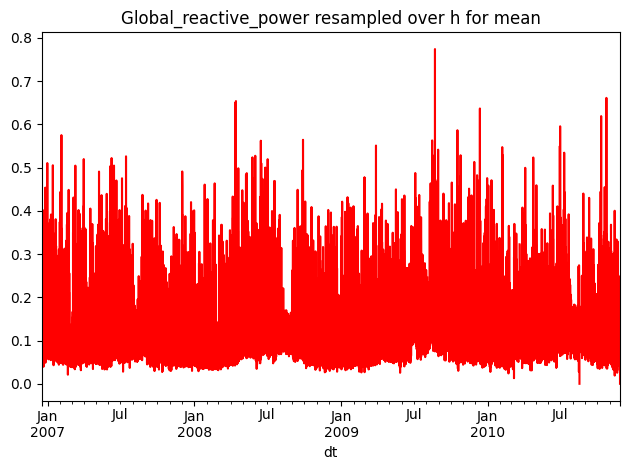

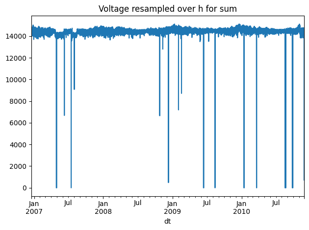

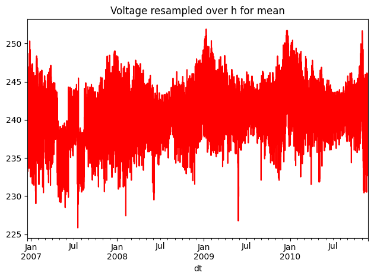

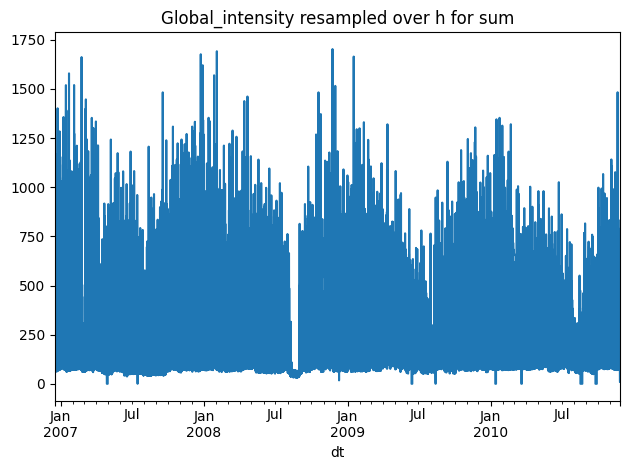

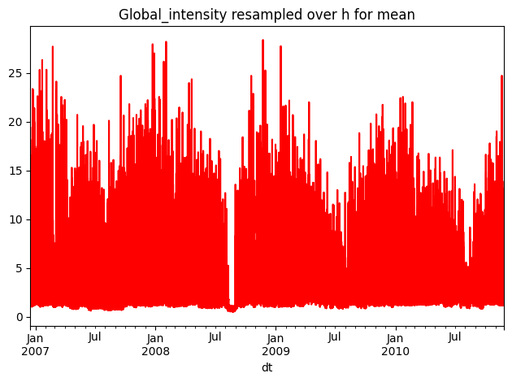

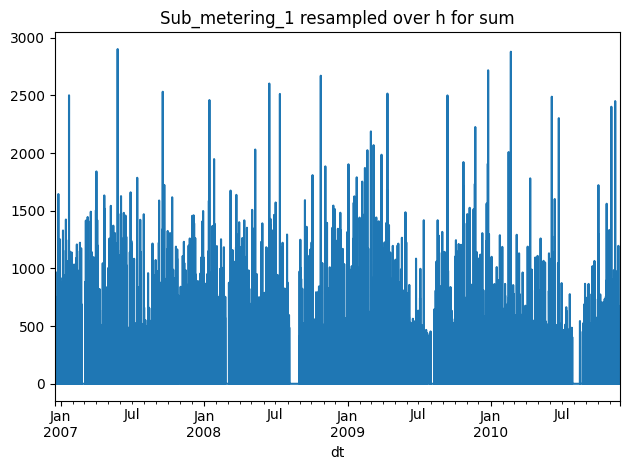

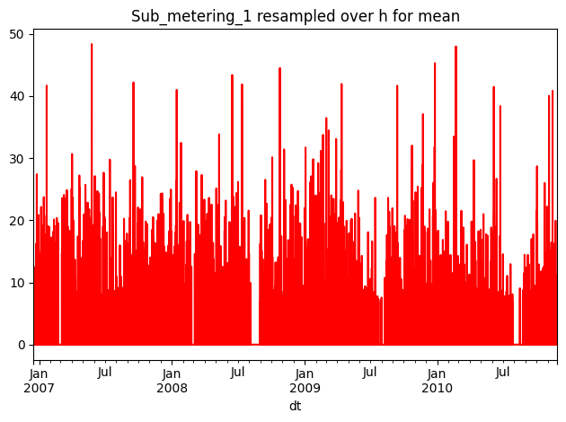

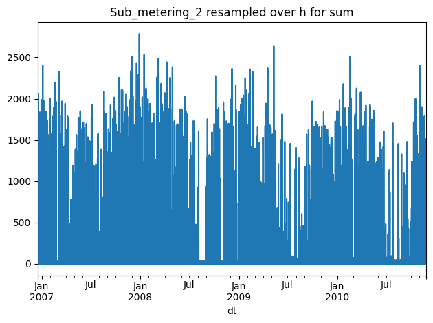

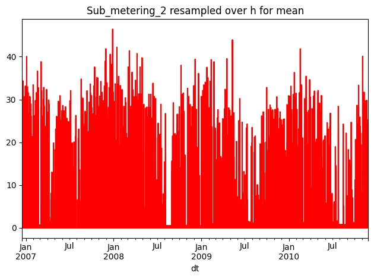

[2 more figures not shown]

```python
for col in data.columns:
    trend_plot(col, 'h')
```

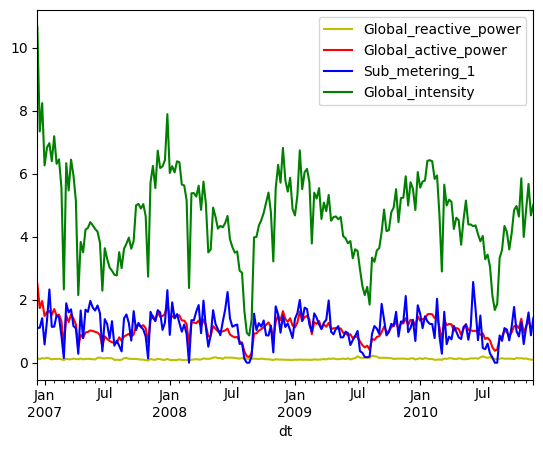

```python
data.Global_reactive_power.resample('W').mean().plot(color='y', legend=True)
data.Global_active_power.resample('W').mean().plot(color='r', legend=True)
data.Sub_metering_1.resample('W').mean().plot(color='b', legend=True)
data.Global_intensity.resample('W').mean().plot(color='g', legend=True)
plt.show()
```

Совпадение формы графиков суммы и среднего означает стабильный, равномерно измеряемый показатель с реальным долгосрочным трендом, не искажённым пропусками или выбросами.

Графики отчетливо показывает сезонные тренды.

# Выбросы (Outliers)

```python
data
```

| dt | Global_active_power | Global_reactive_power | Voltage | Global_intensity | Sub_metering_1 | Sub_metering_2 | Sub_metering_3 |
| --- | --- | --- | --- | --- | --- | --- | --- |
| 2006-12-16 17:24:00 | 4.216 | 0.418 | 234.84 | 18.4 | 0.0 | 1.0 | 17.0 |
| 2006-12-16 17:25:00 | 5.360 | 0.436 | 233.63 | 23.0 | 0.0 | 1.0 | 16.0 |
| 2006-12-16 17:26:00 | 5.374 | 0.498 | 233.29 | 23.0 | 0.0 | 2.0 | 17.0 |
| 2006-12-16 17:27:00 | 5.388 | 0.502 | 233.74 | 23.0 | 0.0 | 1.0 | 17.0 |
| 2006-12-16 17:28:00 | 3.666 | 0.528 | 235.68 | 15.8 | 0.0 | 1.0 | 17.0 |
| ... | ... | ... | ... | ... | ... | ... | ... |
| 2010-11-26 20:58:00 | 0.946 | 0.000 | 240.43 | 4.0 | 0.0 | 0.0 | 0.0 |
| 2010-11-26 20:59:00 | 0.944 | 0.000 | 240.00 | 4.0 | 0.0 | 0.0 | 0.0 |
| 2010-11-26 21:00:00 | 0.938 | 0.000 | 239.82 | 3.8 | 0.0 | 0.0 | 0.0 |
| 2010-11-26 21:01:00 | 0.934 | 0.000 | 239.70 | 3.8 | 0.0 | 0.0 | 0.0 |
| 2010-11-26 21:02:00 | 0.932 | 0.000 | 239.55 | 3.8 | 0.0 | 0.0 | 0.0 |

2075259 rows × 7 columns

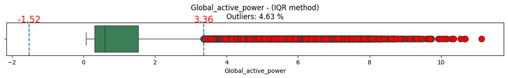

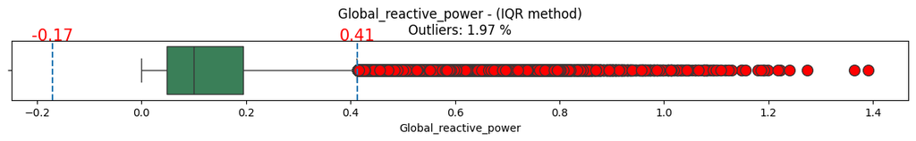

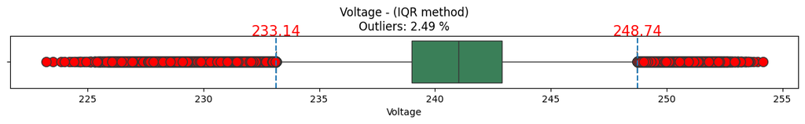

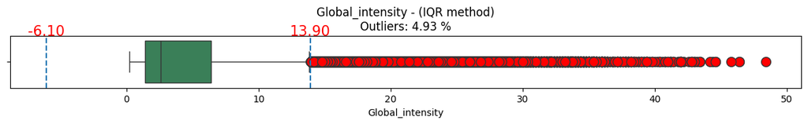

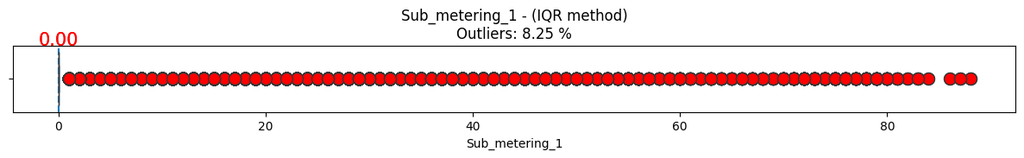

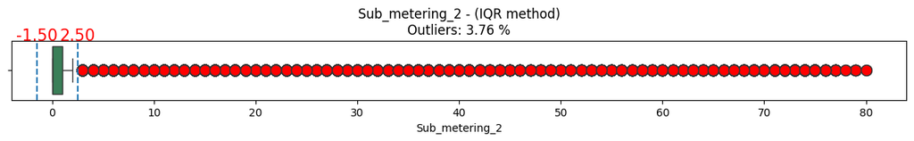

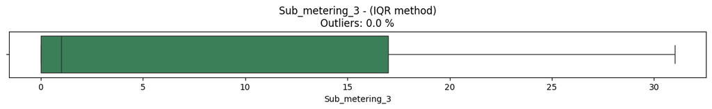

```python
data_to_outliers = data.copy()

for column in data_to_outliers.columns:
    plt.figure(figsize=(15, 1))

    flier_style = dict(marker='o', markerfacecolor='r', markersize=10)

    # данные по одному столбцу
    col_data = data_to_outliers[column].dropna()
    n = len(col_data)

    # вычисление границ выбросов по IQR ДЛЯ ЭТОГО СТОЛБЦА
    Q1 = col_data.quantile(0.25)
    Q3 = col_data.quantile(0.75)
    IQR = Q3 - Q1
    lower_bound = Q1 - 1.5 * IQR
    upper_bound = Q3 + 1.5 * IQR

    # выбросы
    outliers = col_data[(col_data < lower_bound) | (col_data > upper_bound)]
    outlier_count = len(outliers)
    outlier_percent = round(100 * outlier_count / n, 2)

    # boxplot
    sns.boxplot(x=col_data, color='SeaGreen', flierprops=flier_style)

    if outlier_percent > 0:
        plt.axvline(lower_bound, linestyle='--')
        plt.axvline(upper_bound, linestyle='--')
        plt.text(lower_bound, -0.5, f"{lower_bound:.2f}", color='r', fontsize=15, ha='center')
        plt.text(upper_bound, -0.5, f"{upper_bound:.2f}", color='r', fontsize=15, ha='center')

    plt.title(f"{column} - (IQR method)\nOutliers: {outlier_percent} %")
    plt.show()
```

Интерпретация выбросов:

Это не шум, а реальные пики нагрузки

Выбросы — это:

- включение бойлера
- духовка
- стиральная машина
- обогреватель

То есть выбросы несут информацию, а не ошибку.

# Рекомендации к инженерии переменных:

- Ресемплирование признаков в соответствии c физическим смыслом.

Мгновенные величины по среднему значению.

`Global_active_power, Global_reactive_power, Voltage, Global_intensity`

Накопленные величины по сумме.

`Sub_metering_1, Sub_metering_2, Sub_metering_3`

- Обязательная обработка пропусков с учетом мульти сезонности и тренда.
- Сохранение выбросов, во избежании потери информации по пикам нагрузки. Использование методов уменьшающих влияние выбросов.
- Создание фич лагов, календарные фичи, которые отражают сезонность, тренды и зависимости нагрузки от времени, выходных и будней.
- Масштабирование признаков. Рекуррентные сети чувствительны к масштабу входа.